# Makeover Monday 2020w36

80 Cereals - Kaggle

Billy Caughey

2020-09-07

## Introduction

This week's Makeover Monday will be a bit different this week. Instead of a dashboard submission, a traditional analysis report will be submitted. The focus of this week is around Kaggle's data set [80 Cereals](https://www.kaggle.com/crawford/80-cereals?select=cereal.csv) based on the article ["Breakfast Cereals: Healthy or Unhealthy?"](https://www.healthline.com/nutrition/are-breakfast-cereals-healthy). There are two goals to this submission. First, develop a model to detect if a cereal is 'hot' or 'cold'. There are several methods that can be used here: logistic regression, linear descriminate analysis, and random forests to name a few. Additionally, the hope is to 'bag' these methods. Bagging will be discussed later. Second, present a walk through on how to perform a cluster anlaysis. This will include discussion methods, libraries, and functions used in this markdown.

## Preprocessing

This step of the data analytics pathway is all about importing and cleaning the data. Both steps of importing and cleaning can present issues. Importing data requires understanding where the data is stored and how to get it into R. Cleaning requires a quick exploration and making corrections based on logic rules.

### Importing data

The data for this project is stored on [data.world](https://data.world/makeovermonday/2020w36). To bring in the data, the `httr` and `readxl` libraries will be used. The `httr` library is used in working with URLs and HTTP. The `readxl` library will be used to import the downloaded excel sheet into R. The first row of the excel sheet will be 'skipped' so the row names can be detected by R upon import.

```r
library(httr)
library(readxl)

invisible(capture.output(GET("https://query.data.world/s/sxpiyi2oqau6qbc54fnwkov5xuzcr4", write_disk(tf <- tempfile(fileext = ".xlsx")))))
df <- read_excel(tf, col_names = TRUE, skip = 1)

str(df)
```

```
## tibble [77 × 16] (S3: tbl_df/tbl/data.frame)
##  $ name                                           : chr [1:77] "Apple Cinnamon Cheerios" "Basic 4" "Cheerios" "Cinnamon Toast Crunch" ...
##  $ Manufacturer                                   : chr [1:77] "General Mills" "General Mills" "General Mills" "General Mills" ...
##  $ type                                           : chr [1:77] "Cold" "Cold" "Cold" "Cold" ...
##  $ calories per serving                           : num [1:77] 110 130 110 120 110 110 110 100 110 110 ...
##  $ grams of protein                               : num [1:77] 2 3 6 1 3 1 1 2 1 3 ...
##  $ grams of fat                                   : num [1:77] 2 2 2 3 2 1 1 1 1 1 ...
##  $ milligrams of sodium                           : num [1:77] 180 210 290 210 140 180 180 140 280 250 ...
##  $ grams of dietary fiber                         : num [1:77] 1.5 2 2 0 2 0 0 2 0 1.5 ...
##  $ grams of complex carbohydrates                 : num [1:77] 10.5 18 17 13 13 12 12 11 15 11.5 ...
##  $ grams of sugars                                : num [1:77] 10 8 1 9 7 13 13 10 9 10 ...
##  $ milligrams of potassium                        : num [1:77] 70 100 105 45 105 55 65 120 45 90 ...
##  $ vitamins and minerals (% of FDA recommendation): num [1:77] 25 25 25 25 25 25 25 25 25 25 ...
##  $ Display shelf                                  : num [1:77] 1 3 1 2 3 2 2 3 2 1 ...
##  $ Weight in ounces per one serving               : num [1:77] 1 1.33 1 1 1 1 1 1 1 1 ...
##  $ Number of cups in one serving                  : num [1:77] 0.75 0.75 1.25 0.75 0.5 1 1 0.75 0.75 0.75 ...
##  $ Rating of cereal                               : num [1:77] 29.5 37 50.8 19.8 40.4 ...
```

### Data Cleaning

There are two very quick methods to determine what cleaning efforts need to be taken. First, the `missmap` function from the `Amelia` function. The result, known as a Missingness Map, will show where missing values exist and give a sense of the frequency. If there are missing values, logic rules will need to be applied to address these missing values.

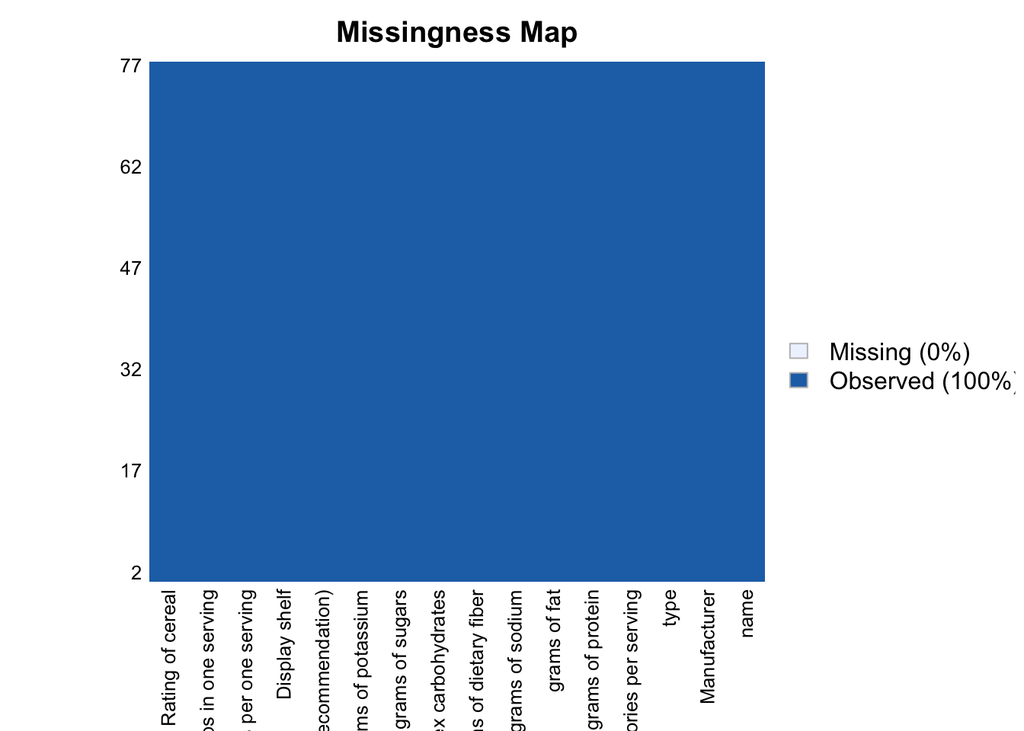

```r
library(Amelia)

missmap(df)
```

The resulting Missingness Map shows there are no missing values. In practice, this may not always be the case. Large efforts will often be applied to correct missing values when necessary.

The second method is to use the `summary` function. The results of this function are the mean and 5-number summary of each numeric field. Outliers can be seen very easily using this method.

```r
summary(df)
```

```
##      name           Manufacturer           type           calories per serving
##  Length:77          Length:77          Length:77          Min.   : 50.0
##  Class :character   Class :character   Class :character   1st Qu.:100.0
##  Mode  :character   Mode  :character   Mode  :character   Median :110.0
##                                                           Mean   :106.9
##                                                           3rd Qu.:110.0
##                                                           Max.   :160.0
##  grams of protein  grams of fat   milligrams of sodium grams of dietary fiber
##  Min.   :1.000    Min.   :0.000   Min.   :  0.0        Min.   : 0.000
##  1st Qu.:2.000    1st Qu.:0.000   1st Qu.:130.0        1st Qu.: 1.000
##  Median :3.000    Median :1.000   Median :180.0        Median : 2.000
##  Mean   :2.545    Mean   :1.013   Mean   :159.7        Mean   : 2.152
##  3rd Qu.:3.000    3rd Qu.:2.000   3rd Qu.:210.0        3rd Qu.: 3.000
##  Max.   :6.000    Max.   :5.000   Max.   :320.0        Max.   :14.000
##  grams of complex carbohydrates grams of sugars  milligrams of potassium
##  Min.   :-1.0                   Min.   :-1.000   Min.   : -1.00
##  1st Qu.:12.0                   1st Qu.: 3.000   1st Qu.: 40.00
##  Median :14.0                   Median : 7.000   Median : 90.00
##  Mean   :14.6                   Mean   : 6.922   Mean   : 96.08
##  3rd Qu.:17.0                   3rd Qu.:11.000   3rd Qu.:120.00
##  Max.   :23.0                   Max.   :15.000   Max.   :330.00
##  vitamins and minerals (% of FDA recommendation) Display shelf
##  Min.   :  0.00                                  Min.   :1.000
##  1st Qu.: 25.00                                  1st Qu.:1.000
##  Median : 25.00                                  Median :2.000
##  Mean   : 28.25                                  Mean   :2.208
##  3rd Qu.: 25.00                                  3rd Qu.:3.000
##  Max.   :100.00                                  Max.   :3.000
##  Weight in ounces per one serving Number of cups in one serving
##  Min.   :0.50                     Min.   :0.250
##  1st Qu.:1.00                     1st Qu.:0.670
##  Median :1.00                     Median :0.750
##  Mean   :1.03                     Mean   :0.821
##  3rd Qu.:1.00                     3rd Qu.:1.000
##  Max.   :1.50                     Max.   :1.500
##  Rating of cereal
##  Min.   :18.04
##  1st Qu.:33.17
##  Median :40.40
##  Mean   :42.67
##  3rd Qu.:50.83
##  Max.   :93.70
```

One of the first observations is the value of -1 in **grams of sugar**, **grams of complex carbohydrates** and, **milligrams of potassium**. This does not make sense any sense to have a value of -1 for any of these values! The cereals which report -1 in these fields are:

```r
library(tidyverse)

df %>%
    filter(`grams of sugars` == -1 | `milligrams of potassium` == -1 | `grams of complex carbohydrates` == -1) %>%
    select(name, `grams of sugars`, `milligrams of potassium`, `grams of complex carbohydrates`)
```

```
## # A tibble: 3 x 4
##   name           `grams of sugars` `milligrams of pota… `grams of complex carbo…
##   <chr>                      <dbl>                <dbl>                    <dbl>
## 1 Almond Delight                 8                   -1                       14
## 2 Cream of Whea…                 0                   -1                       21
## 3 Quaker Oatmeal                -1                  110                       -1
```

It appears the -1 value points to a *missing* entry. A quick Google search can be used to find out what these values actually should be. This highlights an important point. Always take a few minutes to do some digging to determine what the truth is. The previous code to print out the names of cereals with a '-1' will be used to determine if the problem was corrected.

```r
df <- df %>%
    mutate(`milligrams of potassium` = ifelse(name == "Almond Delight", 155, ifelse(name == "Cream of Wheat (Quick)", 0, `milligrams of potassium`)),
           `grams of sugars` = ifelse(name == "Quaker Oatmeal", 0, `grams of sugars`),
           `grams of complex carbohydrates` = ifelse(name == "Quaker Oatmeal", 22, `grams of complex carbohydrates`))

df %>%
    filter(`grams of sugars` == -1 | `milligrams of potassium` == -1 | `grams of complex carbohydrates` == -1) %>%
    select(name, `grams of sugars`, `milligrams of potassium`, `grams of complex carbohydrates`)
```

```
## # A tibble: 0 x 4
## # … with 4 variables: name <chr>, `grams of sugars` <dbl>, `milligrams of
## #   potassium` <dbl>, `grams of complex carbohydrates` <dbl>
```

## Exploratory Data Analysis (EDA)

Before developing a model, it is wise to explore the data. Descriptive and visual methods will be used to explore the data. Insights from this exploration will drive hypothesis testing, variable inclusion, and potential models which can be used. Additionally, there is a touch of crossover between EDA and data cleaning. Before a model is coded, data should be scaled and centered (known as standardizing). The purpose for this is to remove units and standardize data. Classification models often work better when data is standardized as well. It should be noted at this point that forest models are 'immune' to outliers. The data will still be standardized to maintain consistency across models.

Exploring the data will require the use of the Tidyverse using the `tidyverse` library. This library contains tools for importing, cleaning, and visualizing data. When an R user imports the `tidyverse`, a myriad of libraries are imported. These libraries include, but not limited to `tidyR`, `dplyr`, and `ggplot2`.

### Reviewing Outcome Variable: type

Let's take a moment and see how many of each type of cereal the data contains. If 'type' of cereal is an extreme event, the crossvalidation method used later will need to be adjusted to address to this.

```r
round(prop.table(table(df$type)) * 100, 3)
```

```
##
##   Cold    Hot
## 96.104  3.896
```

Two immediate thoughts come from this result. First, there is no surprise coming from this result. The cereal aisle at the local grocery store will reflect this result. Second, the outcome of 'hot' cereal is definitely a rare event. Rare events cause a host of issues because classification models make the assumption outcome classes are balances. There are several methods can address rare events. Since sampling will be handled by cross-validation, a method like gradient boosting can be used (discussed later).

### Reviewing Input Variables